# Analyse en Composantes Principales

Jeu de données test_fwd_dom

Ce jeu de données contient 24 individus et 17 variables.

### 1. Observation d’individus extrêmes

L’analyse des graphes ne révèle aucun individu singulier.

### 2. Distribution de l’inertie

L’inertie des axes factoriels indique d’une part si les variables sont structurées et suggère d’autre part le nombre judicieux de composantes principales à étudier.

Les 2 premiers axes de l’ analyse expriment **47.66%** de l’inertie totale du jeu de données ; cela signifie que 47.66% de la variabilité totale du nuage des individus (ou des variables) est représentée dans ce plan. C’est un pourcentage relativement moyen, et le premier plan représente donc seulement une part de la variabilité contenue dans l’ensemble du jeu de données actif. Cette valeur est supérieure à la valeur référence de **34.01%**, la variabilité expliquée par ce plan est donc significative (cette intertie de référence est le quantile 0.95-quantile de la distribution des pourcentages d’inertie obtenue en simulant 6145 jeux de données aléatoires de dimensions comparables sur la base d’une distribution normale).

Du fait de ces observations, il serait alors probablement nécessaire de considérer également les dimensions supérieures ou égales à la troisième dans l’analyse.

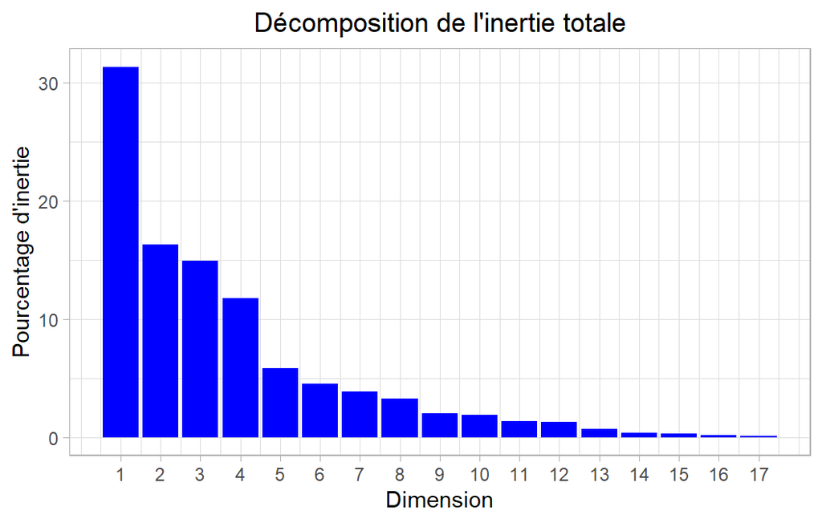

**Figure 2 - Décomposition de l’inertie totale**

Une estimation du nombre pertinent d’axes à interpréter suggère de restreindre l’analyse à la description des 4 premiers axes. Ces composantes révèlent un taux d’inertie supérieur à celle du quantile 0.95-quantile de distributions aléatoires (74.33% contre 56.73%). Cette observation suggère que seuls ces axes sont porteurs d’une véritable information. En conséquence, la description de l’analyse sera restreinte à ces seuls axes.

### 3. Description du plan 1:2

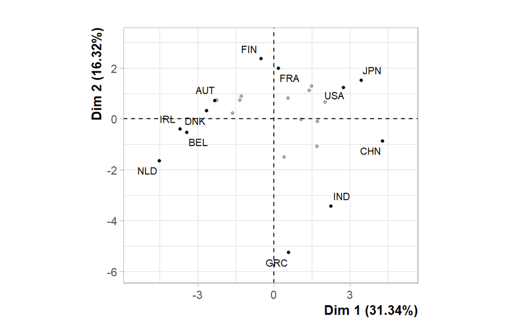

**Figure 3.1 - Graphe des individus (ACP)** *Les individus libellés sont ceux ayant la plus grande contribution à la construction du plan.*

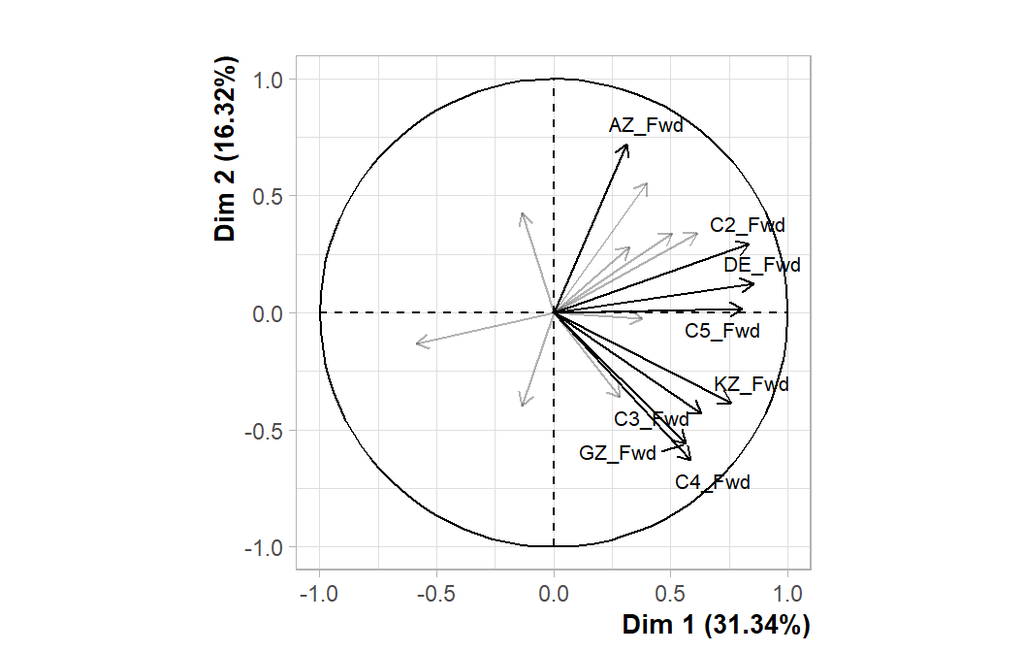

**Figure 3.2 - Graphe des variables (ACP)** *Les variables libellées sont celles les mieux représentées sur le plan.*

Le groupe auquel les individus *NLD*, *BEL*, *DNK*, *IRL* et *AUT* appartiennent (caractérisés par une coordonnées négative sur l’axe) partage :

- de faibles valeurs pour les variables *DE_Fwd*, *C5_Fwd*, *KZ_Fwd*, *C3_Fwd*, *C2_Fwd*, *HZ_Fwd* et *C4_Fwd* (de la plus extrême à la moins extrême).

Le groupe auquel les individus *GRC* et *IND* appartiennent (caractérisés par une coordonnées négative sur l’axe) partage :

- de fortes valeurs pour les variables *GZ_Fwd*, *C4_Fwd*, *C3_Fwd* et *KZ_Fwd* (de la plus extrême à la moins extrême).
- de faibles valeurs pour la variable *OQ_Fwd*.

### 4. Description du plan 3:4

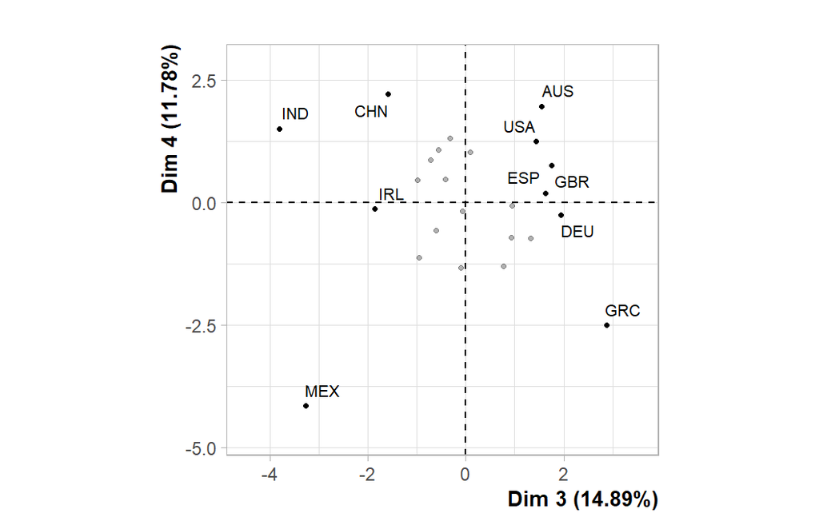

**Figure 4.1 - Graphe des individus (ACP)** *Les individus libellés sont ceux ayant la plus grande contribution à la construction du plan.*

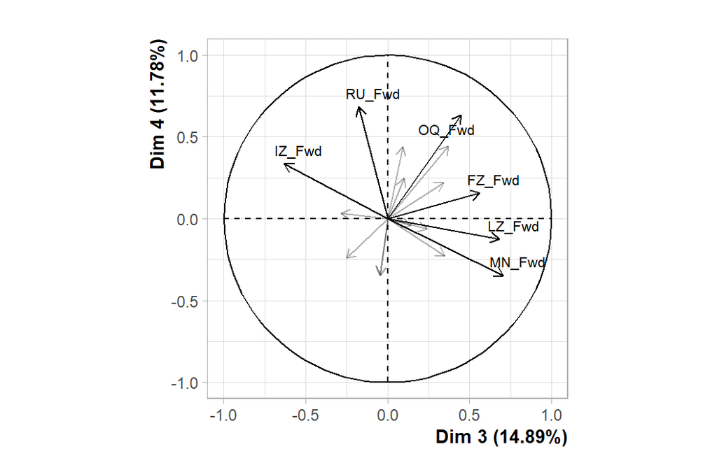

**Figure 4.2 - Graphe des variables (ACP)** *Les variables libellées sont celles les mieux représentées sur le plan.*

La **dimension 3** oppose des individus tels que *AUS*, *DEU*, *GRC*, *GBR*, *USA* et *ESP* (à droite du graphe, caractérisés par une coordonnée fortement positive sur l’axe) à des individus comme *MEX*, *IND*, *CHN* et *IRL* (à gauche du graphe, caractérisés par une coordonnée fortement négative sur l’axe).

Le groupe auquel les individus *AUS*, *DEU*, *GRC*, *GBR*, *USA* et *ESP* appartiennent (caractérisés par une coordonnée positive sur l’axe) partage :

- de fortes valeurs pour les variables *MN_Fwd*, *HZ_Fwd*, *LZ_Fwd* et *C3_Fwd* (de la plus extrême à la moins extrême).
- de faibles valeurs pour la variable *IZ_Fwd*.

Le groupe auquel l’individu *MEX* appartient (caractérisés par une coordonnées négative sur l’axe) partage :

- de fortes valeurs pour la variable *AZ_Fwd*.
- de faibles valeurs pour la variable *OQ_Fwd*.

Le groupe auquel les individus *IND*, *CHN* et *IRL* appartiennent (caractérisés par une coordonnées négative sur l’axe) partage :

- de fortes valeurs pour la variable *IZ_Fwd*.
- de faibles valeurs pour les variables *MN_Fwd* et *C5_Fwd* (de la plus extrême à la moins extrême).

## Annexes

```r
dimdesc(res, axes = 1:4)
```

```
$Dim.1

Link between the variable and the continuous variables (R-square)
=================================================================================
       correlation      p.value
DE_Fwd   0.8531679 1.175751e-07
C2_Fwd   0.8359296 3.663288e-07
C5_Fwd   0.8073008 1.864459e-06
KZ_Fwd   0.7612391 1.561507e-05
C3_Fwd   0.6330630 8.993173e-04
JZ_Fwd   0.6152063 1.376340e-03
C4_Fwd   0.5867439 2.580070e-03
GZ_Fwd   0.5639703 4.100237e-03
HZ_Fwd   0.5075135 1.135632e-02
FZ_Fwd  -0.5890368 2.457902e-03

$Dim.2

Link between the variable and the continuous variables (R-square)
=================================================================================
       correlation      p.value
AZ_Fwd   0.7213248 6.963315e-05
C1_Fwd   0.5549582 4.881718e-03
OQ_Fwd   0.4252550 3.830131e-02
C3_Fwd  -0.4298018 3.606598e-02
GZ_Fwd  -0.5591965 4.499899e-03
C4_Fwd  -0.6303786 9.603174e-04

$Dim.3

Link between the variable and the continuous variables (R-square)
=================================================================================
       correlation      p.value
MN_Fwd   0.7065291 0.0001138818
LZ_Fwd   0.6825902 0.0002378877
FZ_Fwd   0.5621645 0.0042477543
OQ_Fwd   0.4479552 0.0281505786
IZ_Fwd  -0.6312848 0.0009393403

$Dim.4

Link between the variable and the continuous variables (R-square)
=================================================================================
       correlation      p.value
RU_Fwd   0.6836658 0.0002304761
OQ_Fwd   0.6346695 0.0008644286
HZ_Fwd   0.4436914 0.0298711767
C1_Fwd   0.4407149 0.0311213437
```

**Figure 5 - Liste des variables caractéristiques des dimensions de l’analyse.**